# Extensiones del Modelo de Koyck - Universidad Nacional del Callao Econometria II

Ismael Aguedo Aguilar, …

2023-06-20

# Repositorio del proyecto en GitHub 😁

🎉 Aquí está nuestro [repositorio](https://github.com/Ismael-Aguedo). ¡Siéntete libre de visitarlo! 👍

Bien ahora como trabajo de fin de curso mi grupo presentara algunas aplicaciones de las Extensiones del Modelo de Koyck, para ello primero detallamos una breve teoría y luego evaluamos nuestro caso.

# Cambio tecnológico y la demanda de computadoras

Este estudio analiza el crecimiento del uso de las computadoras electrónicas en los Estados Unidos de 1955 a 1965. Se utiliza el enfoque de medir el crecimiento natural y el inducido por cambios tecnológicos, considerando las ecuaciones diferenciales Gompertz y logística. Además, se examina la relación entre los precios y la demanda, y se observa una disminución anual del 20% en los precios.

## 1. Curva de Gompertz

$$T(t)=T^{*}b^{e^{-rt}}$$

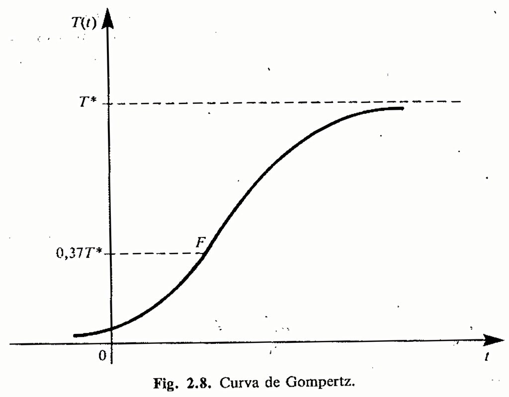

De la ecuación de la curva es fácil deducir:

$$\frac{d[\ln T(t)]}{dt}=-r(\ln
b)e^{-rt}$$
En efecto dado que se $<<estandariza>>$ $T(t)$ tomando sus unidades de manera que $T^{*}=1$.

**Ecuación diferencial e hipótesis de crecimiento**

$$\frac{d[\ln T(t)]}{dt}=r[\ln T^{*}-\ln
T(t)] \qquad \color{red}{(*)}$$
**Aproximación Discreta**

$$\ln \frac{X_{t}}{X_{t-1}}=a\ln
X^{*}-a\ln X_{t-1}+\mu_{t}$$
Gregory Chow usa la curva de Gompertz dado que es mejor que la logística en ocasiones donde el crecimiento aumenta rápidamente al principio y declina lentamente al final del proceso.

## 2. Modelo de Ajuste Parcial

Bajo el concepto de equilibrio de largo plazo se introduce la notación $Y^{*}$:

$$Y^{*}_{t}=\alpha+\beta
X_{t}+\mu_{t}$$

El supuesto básico de *Ajuste Parcial* es el siguiente:

**Tiempo continuo**

$$\frac{dY(t)}{dt}=\delta\left[Y^{*}(t)-Y(T)\right]$$

**Tiempo discreto**

$$Y_{t}-Y_{t-1}=\delta
\left(Y^{*}_{t}-Y_{t-1}\right) \qquad \color{green}{(**)}$$

Donde $0<\delta\leq1$, condición estabilidad y no negatividad.

**El modelo**

Entonces ahora podemos eliminar $Y^{*}_{t}$ sustituyendo en la ecuación anterior, obteniendo:

$$Y_{t}=\alpha\delta+\delta\beta
X_{t}+\left(1-\delta\right)+\delta\mu_{t}$$

## 3. Desarrollando la Aplicación

De el modelo de Ajuste Parcial mencionado anteriormente necesitamos ajustar el modelo más complejo para usar la ecuación diferencial que da origen a la curva de Gompertz, suponiendo que $\delta$ es una función de $Y_{T}$ si se admite que:

$$\delta=kY(t)$$
De acuerdo a lo mencionado en el apartado 1 podemos usar $\color{red}{(*)}$ y por analogía:

$$\frac{d[\ln Y(t)]}{dt}=r\left[\ln
Y^{*}(t)-\ln Y(t)\right]$$

Análogamente a $\color{green}{(**)}$ y en tiempo discreto:

$$\ln Y_{t}-\ln Y_{t-1}=a\left(\ln
Y^{*}_{t}-\ln Y_{t-1}\right) \qquad \color{blue}{(*)}$$
**Dando forma de acuerdo al Cambio Tecnológico y Demanda de Computadoras**

$$\ln Y^{*}_{t}=\alpha+\beta_{1}\ln
P_{t}+\beta_{2}\ln X_{t}+\mu_{t}$$
Remplazando en $\color{blue}{(*)}$ tenemos el modelo de AJUSTE PARCIAL siguiente:

$$ln Y_{t}=\alpha a+\beta_{1}a\ln
P_{t}+\beta_{2}a\ln X_{t}+(1-a)\ln Y_{t-1}+a\mu_{t}$$

### La base de datos:

```r
demandaPCGregoryChow
```

| Año | yt | pt | lnyt0 | lnpt | lnytvsyt0 | yt0 | ytvsyt0 |
| --- | --- | --- | --- | --- | --- | --- | --- |
| 1954 | 370.26 | 3.2554 | NA | 1.180315 | NA | NA | NA |
| 1955 | 991.67 | 2.9610 | 5.914205 | 1.085527 | 0.985070 | 370.26 | 2.678 |
| 1956 | 2389.90 | 2.5336 | 6.899390 | 0.929641 | 0.879627 | 991.67 | 2.410 |
| 1957 | 5087.60 | 2.3168 | 7.779007 | 0.840187 | 0.755652 | 2389.90 | 2.129 |
| 1958 | 8362.00 | 2.0342 | 8.534561 | 0.710103 | 0.497132 | 5087.60 | 1.644 |
| 1959 | 12549.00 | 1.5884 | 9.031453 | 0.462727 | 0.406132 | 8362.00 | 1.501 |
| 1960 | 19072.00 | 1.0716 | 9.437396 | 0.069153 | 0.418710 | 12549.00 | 1.520 |
| 1961 | 38264.00 | 0.9042 | 9.855977 | -0.100705 | 0.696143 | 19072.00 | 2.006 |
| 1962 | 64349.00 | 0.6873 | 10.552260 | -0.374984 | 0.519984 | 38264.00 | 1.682 |
| 1963 | 95815.00 | 0.5712 | 11.072080 | -0.560016 | 0.398105 | 64349.00 | 1.489 |

[output cut: 2 more lines]

Donde:

- **yt:** Es el índice de cantidad de ordenadores adquiridos.
- **pt:** Precio del bien.
- **yt0** Es la variable yt rezagada en un periodo.
- **ytvsyt0** Es la división entre $Y_{y}$ y $Y_{t-1}$.

### Evaluando el Modelo de Gregory Chow

$$ln \frac{Y_{t}}{Y_{t-1}}=\alpha
a+\beta_{1}a\ln P_{t}-\ln Y_{t-1}+a\mu_{t}$$
Gregory Chow evalua el modelo sin considerar la variable $X_{t}$ el cual hace referencia a la remuneración de los posibles compradores de los ordenadores, para poder evaluar directamente como influye el precio y el índice de ordenadores adquiridos en periodos pasados, el resultado obtenido se refleja en la siguiente tabla.

```r
modelo <- lm(lnytvsyt0 ~ lnpt + lnyt0, data = demandaPCGregoryChow, na.action = na.exclude)
summary(modelo)
```

```
Call:
lm(formula = lnytvsyt0 ~ lnpt + lnyt0, data = demandaPCGregoryChow,
    na.action = na.exclude)

Residuals:
     Min       1Q   Median       3Q      Max
-0.13100 -0.04335 -0.03849  0.05474  0.18553

Coefficients:
            Estimate Std. Error t value Pr(>|t|)
(Intercept)  2.82875    0.64407   4.392  0.00231 **
lnpt        -0.35845    0.16947  -2.115  0.06734 .
lnyt0       -0.23886    0.06734  -3.547  0.00754 **
---
Signif. codes:  0 '***' 0.001 '**' 0.01 '*' 0.05 '.' 0.1 ' ' 1

Residual standard error: 0.1018 on 8 degrees of freedom
  (1 observation deleted due to missingness)
Multiple R-squared:  0.8342,    Adjusted R-squared:  0.7927
F-statistic: 20.12 on 2 and 8 DF,  p-value: 0.0007557
```

### Analizando los resultados

- $R^{2}$ alto, lo cual indica que el modelo puede explicar la variabilidad de del índice de la cantidad de los ordenadores adquiridos.
- La constante $a$ de la curva de Gompertz es 0.23886.
- La elasticidad de la demanda de corto plazo ordenadores frente a $Pt$ es -0.35845.
- La elasticidad de largo plazo es (-0.35845/0.23886) = -1.5